# Identify spikes via a statistical approach

```python
%matplotlib inline
import pandas, numpy, scipy, random
from copy import deepcopy
from scipy.interpolate import interp1d

import matplotlib
import matplotlib.pyplot as plt
import matplotlib.gridspec as gridspec
from mpl_toolkits.axes_grid.anchored_artists import AnchoredText
plt.rc ('font', family='sans-serif')
plt.rc ('font', serif='Computer Modern Roman')
```

## Step 1. Define constants

Besides defining paths where data are stored and dumped, a few constants are defined here specifically to obtain the best performance of the model.

```python
outpath = '/home/elims/elimstuff/noaa_work/DPT_spikes/outputs/'
csvFile = '/home/elims/elimstuff/noaa_work/DPT_spikes/data/8772471_20180801_20190731.csv'

# 1. time period (in day) before each point to be included in the statistical model.
period = 1
# 2. time interval (in minutes) of the time period
interval = int(period * 24 * 60 / 6)
# 3. a threshold on the minimum number of entries for each statistical model
min_entries = 100
# 4. number of bins when building histogram
nbins = 80
# 5. confidence level required of the model in terms of sigma
#cdf_limits = (0.0067, 9933)        # 3sigma
cdf_limits = (0.00023, 0.99977)     # 5sigma
#cdf_limits = (0.000004, 0.9999966) # 6sigma
#cdf_limits = (1.9e-8, 0.999999981) # 7sigma
# 6. a buffer water level to ignore small difference
buffer = 0.15 ## feet
```

## Step 2. Tidy up data

Each row must have a boolean true_is_spike. If True, this data point is labeled as "it is a spike identified by the analyst". Otherwise, the data point is not a true spike. Since the input data does not have such a truth label, it is defined here based on the difference between raw and accepted. If the absolute difference between the two is greater than 0.15 feet, the data point is labeled as "true spike".

```python
# Read CSV file. There are two rows of headers in the CSV file, so we skip the first one.
data = pandas.read_csv(csvFile, skiprows=1)
# Extract the time column and convert them to a series of python-recognized datetime.
time = pandas.to_datetime (data['Time'])
# The converted time will replace the Time column, so delete the default ones.
data = data.drop (['Time', 'Time.1'], axis=1)
# Rename columns of Value and Value.1, which are raw and accepted.
data.columns = ['raw', 'accepted']
# Add three columns:
data['Time'] = time                               # python-recognized datetime
data['delta'] = data.accepted - data.raw          # difference between accepted and raw
data['true_is_spike'] = abs (data.delta) > buffer # truth label of is / is not a spike
```

## Step 3. Look at an example true spike

We first look at the first true spike.

```python
# Find the index of the first true spike
index = data[data.true_is_spike.values].index[0]
point = data.iloc[index]

# Print the water levels at this data point
print (point)
```

```
raw                           11.453
accepted                       8.884
Time             2017-08-05 17:18:00
delta                         -2.569
true_is_spike                   True
Name: 1133, dtype: object
```

The first true spike happens at the 1133-th row of the data frame at time of 2017/08/05 17:18. The observed water level is 11.453 feet, which is 2.569 feet higher than the accepted water level.

To check if this point is truly a spike, we also look at the data 1 day before this data point.

```python
# Check out the data a day before this point
begin_index = index - interval
end_index = index - 1
subdata = data.iloc[begin_index:end_index, :]
print (subdata.describe())
```

```
             raw   accepted  delta
count  239.00000  239.00000  239.0
mean     8.76882    8.76882    0.0
std      0.18162    0.18162    0.0
min      8.44600    8.44600    0.0
25%      8.59900    8.59900    0.0
50%      8.81500    8.81500    0.0
75%      8.94900    8.94900    0.0
max      9.01700    9.01700    0.0
```

A total of 239 data points are available. The mean raw and accepted water levels are the same (8.76882 feet). An important note is that the range of raw water levels is between 8.446 and 9.017 feet. Therefore, the next data point (1133-th) with a raw water level of 11.453 feet is indeed a true spike. We can plot a time series plot to confirm that.

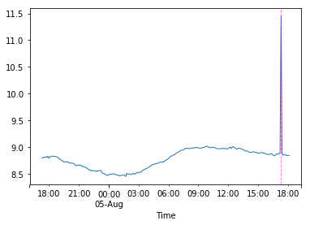

```python
# Include the next 10 data points into subdata to include the is-spike point
subdata = data.iloc[begin_index:end_index+10, :]
# Convert subdata pandas dataframe to a time series panda dataframe
subdata.index = subdata.Time
subdata = subdata.drop('Time', axis=1)

subdata.raw.plot(linewidth=1)
plt.axvline (x=point.Time, color='magenta', alpha=0.5, linestyle='--', linewidth=1)
```

The red vertical line represents the first point of true spike (1133-th row) based on the difference between raw and accepted water levels. It does seem like this data point is a valid spike.

Next we build a statistical model using the data points within the previous day. We first build a histogram using the 239 data points.

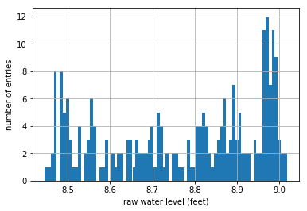

```python
# Extract the relevant data points
subdata = data.iloc[begin_index:end_index, :]
subdata.raw.hist(bins=nbins)
plt.xlabel ('raw water level (feet)')
plt.ylabel ('number of entries')
```

This histogram is converted into a CDF by calculating the cumulative sum of the histogram from left to right.

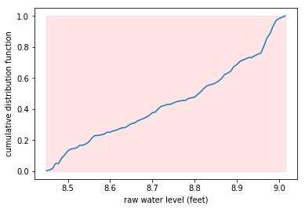

```python
# Calculate the cumulative sum
isfinite = numpy.isfinite (subdata.raw.values)
hist, edges = numpy.histogram (subdata.raw.values[isfinite], bins=nbins)
bincenter = edges[:-1] + (edges[1:] - edges[:-1])/2
cdf = numpy.cumsum (hist/numpy.sum(hist))

plt.plot (bincenter, cdf)
plt.fill_between (x=[min(bincenter), max(bincenter)], y1=cdf_limits[0], y2=cdf_limits[1],
                  color='red', alpha=0.1)
plt.xlabel ('raw water level (feet)')
plt.ylabel ('cumulative distribution function')
```

The yaxis is now a probability in which the next data point is less than or equal to the corresponding xvalue. For example, the probability that the next data point has a raw water level equal to or less than 8.75 feet is roughly 50%. And the probability that the next data point has a raw water level equal to or less than 9.0 is ~100%.

Based on the pre-defined CDF limits (default as 5 sigma), a confident interval of reasonable water level for the next data point is defined as the shaded area. To obtain the exact values of the confident interval, a line is interpolated through the CDF curve such that the raw water level is returned given a probability.

```
Lower & upper limits: 8.449568750000001, 9.0132350758125
```

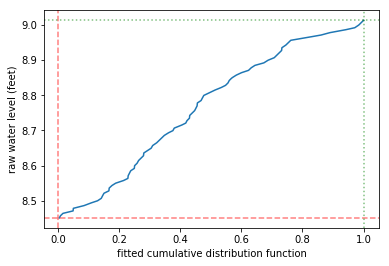

```python
# Fit an inverted line: xvalues = probability & yvalue = raw water level.
icdf = interp1d (cdf, bincenter, bounds_error=False)
# Figure out the water levels at CDF thresholds
lower, upper = icdf(cdf_limits[0]), icdf(cdf_limits[1])
# If they are invalid, re-set to the min / max of the bin centers
if not numpy.isfinite(lower): lower = min (bincenter)
if not numpy.isfinite(upper): upper = max (bincenter)
print ('Lower & upper limits: {0}, {1}'.format(lower, upper))

probabilities = numpy.linspace (0,1, 1000)
raw_water_levels = icdf(probabilities)
plt.plot (probabilities, raw_water_levels)
plt.axvline (cdf_limits[0], color='red', linestyle='--', alpha=0.5)
plt.axhline (lower, color='red', linestyle='--', alpha=0.5)
plt.axvline (cdf_limits[1], color='green', linestyle=':', alpha=0.5)
plt.axhline (upper, color='green', linestyle=':', alpha=0.5)
plt.ylabel ('raw water level (feet)')
plt.xlabel ('fitted cumulative distribution function')
```

This statistical model suggested a confident range is between 8.45 and 9.01 feet. Given that the next point has a raw water level is 11.453 feet, the statistical model says this point is very likely to be a spike. This agrees with the truth label for this point.

## Step 4. Look at an example false spike

Let us repeat the algorithm but this time with a regular non-spike data point. We randomly pick a point from all non-spike data point.

```python
# Randomly pick a point. If it is a true spike, keep randomly pick another point.
random_index = random.sample(range (len (data)), 1)
random_point = data.iloc[random_index]
while random_point.true_is_spike.values[0]:
    random_index = random.sample(range (len (data)), 1)
    random_point = data.iloc[random_index]

point = random_point
print (point)
```

```
        raw  accepted                Time  delta  true_is_spike
3944  8.837     8.837 2017-08-17 10:24:00    0.0          False
```

For most cases, raw and accepted water levels are exactly the same. Some non-spikes data points have a difference between raw and accepted water levels within a buffer of 0.15 feet.

Then, we again look into the data a day before this point.

```python
# Check out the data a day before this point
index = point.index[0]
begin_index = index - interval
end_index = index - 1
subdata = data.iloc[begin_index:end_index, :]

print (subdata.describe())
```

```
              raw    accepted  delta
count  239.000000  239.000000  239.0
mean     8.689038    8.689038    0.0
std      0.199936    0.199936    0.0
min      8.325000    8.325000    0.0
25%      8.505000    8.505000    0.0
50%      8.749000    8.749000    0.0
75%      8.842500    8.842500    0.0
max      9.014000    9.014000    0.0
```

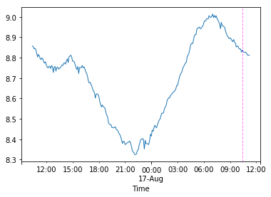

```python
# Include the next 10 data points into subdata to include the is-spike point
subdata = data.iloc[begin_index:end_index+10, :]
# Convert subdata pandas dataframe to a time series panda dataframe
subdata.index = subdata.Time
subdata = subdata.drop('Time', axis=1)

subdata.raw.plot(linewidth=1)
plt.axvline (x=point.Time.values[0], color='magenta',
             alpha=0.5, linestyle='--', linewidth=1)
```

This point is plotted as the vertical red line and is clearly not a spike. Next we build a statistical model using the data points within the previous day. We first build a histogram using the 239 data points.

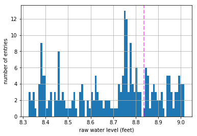

```python
# Extract the relevant data points
subdata = data.iloc[begin_index:end_index, :]
subdata.raw.hist(bins=nbins)
plt.axvline (x=point.raw.values[0], color='magenta',
             alpha=0.5, linestyle='--', linewidth=2)
plt.xlabel ('raw water level (feet)')
plt.ylabel ('number of entries')
```

The raw water level at this point is also plotted as the vertical red line. Again, we create the CDF from this histogram.

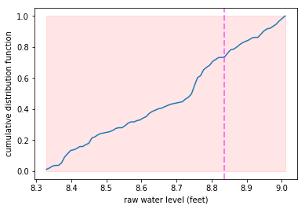

```python
# Calculate the cumulative sum
isfinite = numpy.isfinite (subdata.raw.values)
hist, edges = numpy.histogram (subdata.raw.values[isfinite], bins=nbins)
bincenter = edges[:-1] + (edges[1:] - edges[:-1])/2
cdf = numpy.cumsum (hist/numpy.sum(hist))

plt.plot (bincenter, cdf)
plt.fill_between (x=[min(bincenter), max(bincenter)], y1=cdf_limits[0], y2=cdf_limits[1],
                  color='red', alpha=0.1)
plt.axvline (x=point.raw.values[0], color='magenta',
             alpha=0.5, linestyle='--', linewidth=2)
plt.xlabel ('raw water level (feet)')
plt.ylabel ('cumulative distribution function')
```

As before, the shaded area shows the confident interval based on the pre-defined cdf_limits. The vertical line, indicating the raw water level at the current point, already suggests that the current point is within confident interval. Hence, it is not a spike.

Next, we look into the confident interval from fitted CDF.

```
Lower & upper limits: 8.329306249999998, 9.00957539271875
```

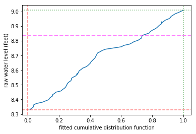

```python
# Fit an inverted line: xvalues = probability & yvalue = raw water level.
icdf = interp1d (cdf, bincenter, bounds_error=False)
# Figure out the water levels at CDF thresholds
lower, upper = icdf(cdf_limits[0]), icdf(cdf_limits[1])
# If they are invalid, re-set to the min / max of the bin centers
if not numpy.isfinite(lower): lower = min (bincenter)
if not numpy.isfinite(upper): upper = max (bincenter)
print ('Lower & upper limits: {0}, {1}'.format(lower, upper))

probabilities = numpy.linspace (0,1, 1000)
raw_water_levels = icdf(probabilities)
plt.plot (probabilities, raw_water_levels)
plt.axhline (y=point.raw.values[0], color='magenta', alpha=0.5,
             linestyle='--', linewidth=2)
plt.axvline (cdf_limits[0], color='red', linestyle='--', alpha=0.5)
plt.axhline (lower, color='red', linestyle='--', alpha=0.5)
plt.axvline (cdf_limits[1], color='green', linestyle=':', alpha=0.5)
plt.axhline (upper, color='green', linestyle=':', alpha=0.5)
plt.ylabel ('raw water level (feet)')
plt.xlabel ('fitted cumulative distribution function')
```

This statistical model suggested a confident range is between 8.33 and 9.01 feet. Given that the next point has a raw water level is 8.837 feet, the statistical model says this point is very likely to not be a spike. This agrees with the truth label for this point.

## Step 5. Loop through all points

Now that we have an algorithm, we want to loop through all the points. For each point, we ...

1. look back a day of data,
2. build a histogram,
3. convert it to CDF,
4. calculates the confident range of water level, and
5. determines if this point is a spike from the confident range.

Here, we first define a function to do all the procedure.

```python
def is_it_a_spike (subdata, previous_spikes, point):

    ''' Input params
        ------------
        subdata (pandas.dataframe): a time series dataframe a day before this point
        previous_spikes (array)   : An array of boolean with a length equal to that of
                                    subdata. All previously identified spikes are removed
                                    from statistical model.
        point (pandas.Series)     : the current point which will be compared to the
                                    statistical model.

        return params
        -------------
        this_is_spike (boolean): If true, input point is a spike.
    '''

    ## Any invalid points in subdata must be excluded from statistical model.
    isfinite = numpy.isfinite (subdata.raw.values)
    ## Any is-spike points in subdata must be excluded from statistical model.
    if len (previous_spikes)>0:
        isfinite = numpy.logical_and (isfinite, ~previous_spikes)
    ## Re-define subdata with valid points.
    subdata = subdata[isfinite]
    ## If there are less valid data than the minimum threshold, there are not
    ## enough information for statistical model. This point is default as not spike.
    if len (subdata) < min_entries:
        print ('+------------------------------------------')
        print ('| {0}-th row: {1} ... '.format(point.name, point.Time))
        print ('|      {0} valid data before current point.'.format(len (subdata)))
        print ('|      Not enough data points - skipping ...')
        return False

    ## Build a histogram of raw water level
    hist, edges = numpy.histogram (subdata.raw.values, bins=nbins)
    bincenter = edges[:-1] + (edges[1:] - edges[:-1])/2
    ## Build CDF
    cdf = numpy.cumsum (hist/numpy.sum(hist))
    ## Fit inverted CDF
    icdf = interp1d (cdf, bincenter, bounds_error=False)
    ## Define the confident interval based on pre-defined cdf limits
    lower, upper = icdf(cdf_limits[0]), icdf(cdf_limits[1])
    if not numpy.isfinite(lower): lower = min (bincenter)
    if not numpy.isfinite(upper): upper = max (bincenter)
    limit_range = [numpy.round (lower, 3)-buffer, numpy.round (upper, 3)+buffer]

    ## Check if this point is a spike
    this_is_spike = point.raw < limit_range[0] or point.raw > limit_range[1]

    ## Print to console if this is a true OR predicted spike.
    if this_is_spike or index in data[data.true_is_spike.values].index:
        nspikes = len(previous_spikes[previous_spikes])
        print ('+------------------------------------------')
        print ('| {0}-th row: {1} ... '.format(index, point.Time))
        print ('|      Last {0} rows has {1} spikes'.format(len (subdata), nspikes))
        print ('|      Confident interval is {0:.5f} - {1:.5f} feet'.format(limit_range[0], limit_range[1]))
        print ('|      This point raw water level is {0:.4f} feet.'.format(point.raw, 5))
        print ('|      Is this point predicted to be a spike? {0}.'.format(this_is_spike))
        print ('|      Is this really a spike? {0}.'.format(data.true_is_spike.values[index]))
        print ('|      Difference between accepted and raw is {0:.4f} feet.'.format (data.delta.values[index]))

    return this_is_spike
```

Now, it is time to loop through all the points. An empty list, are_spikes, is pre-defined to store all predicted is-spike boolean.

```python
are_spikes = []

for index, point in data.iterrows():
    ## By default, this point is not a spike
    this_is_spike = False
    ## Determine the index range.
    begin_index =  max (0, index-interval)
    end_index = max (0, index-1)
    subdata = data.iloc[begin_index:end_index, :]
    ## Only call the functions if there are more than 2 entries
    if len (subdata) >= min_entries:
        previous_spikes = numpy.array (are_spikes[begin_index:end_index])
        this_is_spike = is_it_a_spike (subdata, previous_spikes, point)
    ## Append to holder
    are_spikes.append (this_is_spike)
```

```
+------------------------------------------
| 1133-th row: 2017-08-05 17:18:00 ...
|      Last 239 rows has 0 spikes
|      Confident interval is 8.30000 - 9.16300 feet
|      This point raw water level is 11.4530 feet.
|      Is this point predicted to be a spike? True.
|      Is this really a spike? True.
|      Difference between accepted and raw is -2.5690 feet.
+------------------------------------------
| 1380-th row: 2017-08-06 18:00:00 ...
|      Last 237 rows has 0 spikes
|      Confident interval is 8.28800 - 9.16200 feet
|      This point raw water level is 9.9730 feet.
|      Is this point predicted to be a spike? True.
|      Is this really a spike? True.
|      Difference between accepted and raw is -1.1150 feet.
+------------------------------------------
| 5849-th row: 2017-08-25 08:54:00 ...
|      Last 237 rows has 0 spikes
|      Confident interval is 8.60000 - 9.28200 feet
|      This point raw water level is 9.4800 feet.
|      Is this point predicted to be a spike? True.
|      Is this really a spike? False.
|      Difference between accepted and raw is 0.0000 feet.
+------------------------------------------
| 5874-th row: 2017-08-25 11:24:00 ...
|      Last 238 rows has 1 spikes
|      Confident interval is 8.60100 - 9.44600 feet
|      This point raw water level is 15.6490 feet.
|      Is this point predicted to be a spike? True.
|      Is this really a spike? True.
|      Difference between accepted and raw is -6.2830 feet.
+------------------------------------------
| 5875-th row: 2017-08-25 11:30:00 ...
|      Last 238 rows has 1 spikes
|      Confident interval is 8.60200 - 9.50500 feet
|      This point raw water level is 11.6810 feet.
|      Is this point predicted to be a spike? True.
|      Is this really a spike? True.
|      Difference between accepted and raw is -2.3540 feet.
```

[output cut: 7217 more lines]

```
| 175104-th row: 2019-07-31 14:24:00 ...
|      Last 239 rows has 0 spikes
|      Confident interval is 8.14700 - 9.33400 feet
|      This point raw water level is 18.3990 feet.
|      Is this point predicted to be a spike? True.
|      Is this really a spike? True.
|      Difference between accepted and raw is -9.3770 feet.
+------------------------------------------
| 175105-th row: 2019-07-31 14:30:00 ...
|      Last 238 rows has 1 spikes
|      Confident interval is 8.14700 - 9.33400 feet
|      This point raw water level is 12.8160 feet.
|      Is this point predicted to be a spike? True.
|      Is this really a spike? True.
|      Difference between accepted and raw is -3.8160 feet.
```

## Step 6. Evaluate performance

We include the prediction into a column in data and calculates the confusion matrix.

```python
data['pred_is_spike']= numpy.array (are_spikes)

istrue_notpred  = numpy.logical_and (data.true_is_spike, ~data.pred_is_spike)
nottrue_ispred  = numpy.logical_and (~data.true_is_spike, data.pred_is_spike)
nottrue_notpred = numpy.logical_and (~data.true_is_spike, ~data.pred_is_spike)
istrue_ispred   = numpy.logical_and(data.true_is_spike, data.pred_is_spike)

n_predno_trueno   = len (nottrue_notpred[nottrue_notpred])
n_predyes_trueno  = len (nottrue_ispred[nottrue_ispred])
n_predno_trueyes  = len (istrue_notpred[istrue_notpred])
n_predyes_trueyes = len (istrue_ispred[istrue_ispred])

print ('+-{0:8}-+-{0:8}-+-{0:8}-+'.format('-'*8))
print ('| {0:8} | {1:8} | {2:8} |'.format(' '*8, 'pred no ', 'pred yes'))
print ('+-{0:8}-+-{0:8}-+-{0:8}-+'.format('-'*8))
print ('| {0:8} | {1:8} | {2:8} |'.format('true no ', n_predno_trueno, n_predyes_trueno))
print ('+-{0:8}-+-{0:8}-+-{0:8}-+'.format('-'*8))
print ('| {0:8} | {1:8} | {2:8} |'.format('true yes', n_predno_trueyes, n_predyes_trueyes))
print ('+-{0:8}-+-{0:8}-+-{0:8}-+'.format('-'*8))
```

```
+----------+----------+----------+
|          | pred no  | pred yes |
+----------+----------+----------+
| true no  |   174976 |        4 |
+----------+----------+----------+
| true yes |       25 |      195 |
+----------+----------+----------+
```

We can convert those number to percentage to obtain precision, accuracy, and other rates. Each of the entries in the above matrix is labeled as a number: 1 = pred no & true no; 2 = pred yes & true no; 3 = pred no & true yes; 4 = pred yes & true yes. Below are the definitions of some common performance measurements based on the labels.

- **Accuracy**: (1 + 4) / (1 + 2 + 3 + 4).
- **Precision**: 4 / (2 + 4)
- **Sensitivity / Recal / True Positive Rate**: 4 / (3 + 4)
- **Misclassification / Error Rate**: (2 + 3) / (1 + 2 + 3 + 4)
- **Specificity / True Negative Rate**: 1 / (1 + 2)
- **False Positive Rate**: 2 / (1 + 2)
- **Prevalence**: (3 + 4) / (1 + 2 + 3 + 4)

```python
total = n_predno_trueno + n_predno_trueyes + n_predyes_trueno + n_predyes_trueyes
total_trueyes = n_predno_trueyes + n_predyes_trueyes
total_trueno  = n_predno_trueno  + n_predyes_trueno
total_predyes = n_predyes_trueyes + n_predyes_trueno

accuracy = (n_predno_trueno + n_predyes_trueyes) / total
precision = n_predyes_trueyes / total_predyes
sensitivity = n_predyes_trueyes / total_trueyes
error_rate = (n_predyes_trueno + n_predno_trueyes) / total
true_negative_rate = n_predno_trueno / total_trueno
false_positive_rate = n_predyes_trueno / total_trueno
prevalence = (n_predno_trueyes + n_predyes_trueyes) / total

print ('{0:20}: {1:.5f}'.format('accuracy', accuracy))
print ('{0:20}: {1:.5f}'.format('precision', precision))
print ('{0:20}: {1:.5f}'.format('sensitivity', sensitivity))
print ('{0:20}: {1:.5f}'.format('error rate', error_rate))
print ('{0:20}: {1:.5f}'.format('true negative rate', true_negative_rate))
print ('{0:20}: {1:.5f}'.format('false positive rate', false_positive_rate))
print ('{0:20}: {1:.5f}'.format('prevalence', prevalence))
```

```
accuracy            : 0.99983
precision           : 0.97990
sensitivity         : 0.88636
error rate          : 0.00017
true negative rate  : 0.99998
false positive rate : 0.00002
prevalence          : 0.00126
```

29 data points are worth further investigation. 4 of them are false positive, and 25 are true spikes but predicted as not spikes. Let us first look at the false positive.

```python
# Only show Time, raw, and accepted water levels
print (data[nottrue_ispred].loc[:,['Time', 'raw', 'accepted']])
```

[output not shown]

Let us focus repeat the procedure to build the statistical model for these four points.

```python
for index in data[nottrue_ispred].index:
    point = data.iloc[index]
    begin_index =  max (0, index-interval)
    end_index = max (0, index-1)
    subdata = data.iloc[begin_index:end_index, :]
    previous_spikes = numpy.array (are_spikes[begin_index:end_index])
    this_is_spike = is_it_a_spike (subdata, previous_spikes, point)
    diff
    print ('|      Difference between raw and max range is {0:.4f} feet.',format(diff))
```

[output not shown]

Next, we look into the 25 spikes that are not predicted as spikes.

```python
# Only show Time, raw and accepted water levels, and delta
print (data[istrue_notpred].loc[:,['Time', 'raw', 'accepted', 'delta']])
```

```
                      Time    raw  accepted  delta
5999   2017-08-25 23:54:00  9.704     9.414 -0.290
6089   2017-08-26 08:54:00  9.736     9.550 -0.186
6258   2017-08-27 01:48:00  9.539     9.126 -0.413
6410   2017-08-27 17:00:00  9.268     9.018 -0.250
6658   2017-08-28 17:48:00  9.391     9.199 -0.192
19264  2017-10-20 06:24:00  9.376     9.204 -0.172
28978  2017-11-29 17:48:00  9.164     8.815 -0.349
28982  2017-11-29 18:12:00  9.244     8.783 -0.461
28985  2017-11-29 18:30:00  9.100     8.827 -0.273
30010  2017-12-04 01:00:00  9.286     9.121 -0.165
95678  2018-09-03 15:48:00  9.183     8.916 -0.267
95681  2018-09-03 16:06:00  9.026     8.869 -0.157
95682  2018-09-03 16:12:00  9.091     8.863 -0.228
102366 2018-10-01 12:36:00  9.283     9.066 -0.217
109604 2018-10-31 16:24:00  9.211     8.743 -0.468
112398 2018-11-12 07:48:00  9.475     9.292 -0.183
123261 2018-12-27 14:06:00  9.409     9.105 -0.304
123262 2018-12-27 14:12:00  9.341     9.095 -0.246
123264 2018-12-27 14:24:00  9.346     9.070 -0.276
147535 2019-04-07 17:30:00  9.190     9.040 -0.150
153913 2019-05-04 07:18:00  9.321     9.041 -0.280
161477 2019-06-04 19:42:00  9.227     9.007 -0.220
161682 2019-06-05 16:12:00  9.375     9.217 -0.158
162010 2019-06-07 01:00:00  8.864     8.696 -0.168
166492 2019-06-25 17:12:00  9.155     8.927 -0.228
```

Recall that delta is defined as the difference between accepted and raw water levels. These differences are so small that the model cannot identify them as spikes with a statistical signficance.

## Step 7. Conclusion

This exercise demonstrates a possible statistical approach to identify spikes in regular water level QC procedure. Two years of data at one station is used. At each data point, its previous 1-day non-spike raw water level data are used to calculate a confident range of raw water level if the data point is not a spike. If the raw data is out of the range, then this data point is predicted as a spike. With an accuracy of 99.983%, this model identifies 88.636% of true spikes and mis-identifies 4 (0.002%) non-spikes data points due to small difference between accepted and raw water levels.

A few parameters are tweaked to obtain the best performance. These includes nbins (number of bins when building histograms), cdf_limits (the confidence levels to determine the confident range), buffer (to accept small differences in water levels), and the min_entries (the threshold on number of entries when building histogram). Model performance is most sensitive to nbins because it changes the resolution of the histogram and, hence, the CDF. Buffer also reduces a lot of the false positve cases due to small differences between accepted and raw water levels. Cdf_limits has a limited effect if it is set higher 5σ. One should start a varity of stations with different behavior to ensure those values are valid across all stations. If it is not the case, a minimizer can be built to find the best values for those parameters to maximize performance per station.

Please also note that confusion matrix may not be the best way to measure model performance. Since spikes are rare events, a more careful algorithm such as those for validating hurrican models should be used if time and resources are allowed.